# DATA 606 Data Project Proposal

Puja Roy

### Data Preparation

For this final project proposal, I am planning to leverage the **Drug Use by Age** dataset from FiveThirtyEight https://github.com/fivethirtyeight/data. The reason I chose this dataset is because many people are addicted to drugs ranging from multiple ages and I wanted to explore which ages and what types of drugs certain people are addicted to.

```r
# Load necessary libraries
#install.packages("psych")  # Install the psych package
library(psych)             # Load the psych package
library(dplyr)
library(tidyverse)
# Load the data
drug_data <- read.csv("https://raw.githubusercontent.com/fivethirtyeight/data/master/drug-use-by-age/drug-use-by-age.csv")

# View the structure of the data
str(drug_data)
```

```
## 'data.frame':    17 obs. of  28 variables:
##  $ age                    : chr  "12" "13" "14" "15" ...
##  $ n                      : int  2798 2757 2792 2956 3058 3038 2469 2223 2271 2354 ...
##  $ alcohol_use            : num  3.9 8.5 18.1 29.2 40.1 49.3 58.7 64.6 69.7 83.2 ...
##  $ alcohol_frequency      : num  3 6 5 6 10 13 24 36 48 52 ...
##  $ marijuana_use          : num  1.1 3.4 8.7 14.5 22.5 28 33.7 33.4 34 33 ...
##  $ marijuana_frequency    : num  4 15 24 25 30 36 52 60 60 52 ...
##  $ cocaine_use            : num  0.1 0.1 0.1 0.5 1 2 3.2 4.1 4.9 4.8 ...
##  $ cocaine_frequency      : chr  "5.0" "1.0" "5.5" "4.0" ...
##  $ crack_use              : num  0 0 0 0.1 0 0.1 0.4 0.5 0.6 0.5 ...
##  $ crack_frequency        : chr  "-" "3.0" "-" "9.5" ...
##  $ heroin_use             : num  0.1 0 0.1 0.2 0.1 0.1 0.4 0.5 0.9 0.6 ...
##  $ heroin_frequency       : chr  "35.5" "-" "2.0" "1.0" ...
##  $ hallucinogen_use       : num  0.2 0.6 1.6 2.1 3.4 4.8 7 8.6 7.4 6.3 ...
##  $ hallucinogen_frequency : num  52 6 3 4 3 3 4 3 2 4 ...
##  $ inhalant_use           : num  1.6 2.5 2.6 2.5 3 2 1.8 1.4 1.5 1.4 ...
##  $ inhalant_frequency     : chr  "19.0" "12.0" "5.0" "5.5" ...
##  $ pain_releiver_use      : num  2 2.4 3.9 5.5 6.2 8.5 9.2 9.4 10 9 ...
##  $ pain_releiver_frequency: num  36 14 12 10 7 9 12 12 10 15 ...
##  $ oxycontin_use          : num  0.1 0.1 0.4 0.8 1.1 1.4 1.7 1.5 1.7 1.3 ...
##  $ oxycontin_frequency    : chr  "24.5" "41.0" "4.5" "3.0" ...
##  $ tranquilizer_use       : num  0.2 0.3 0.9 2 2.4 3.5 4.9 4.2 5.4 3.9 ...
##  $ tranquilizer_frequency : num  52 25.5 5 4.5 11 7 12 4.5 10 7 ...
##  $ stimulant_use          : num  0.2 0.3 0.8 1.5 1.8 2.8 3 3.3 4 4.1 ...
##  $ stimulant_frequency    : num  2 4 12 6 9.5 9 8 6 12 10 ...
##  $ meth_use               : num  0 0.1 0.1 0.3 0.3 0.6 0.5 0.4 0.9 0.6 ...
##  $ meth_frequency         : chr  "-" "5.0" "24.0" "10.5" ...
##  $ sedative_use           : num  0.2 0.1 0.2 0.4 0.2 0.5 0.4 0.3 0.5 0.3 ...
##  $ sedative_frequency     : num  13 19 16.5 30 3 6.5 10 6 4 9 ...
```

```r
# Check the first few rows of the data
head(drug_data)
```

```
##   age    n alcohol_use alcohol_frequency marijuana_use marijuana_frequency
## 1  12 2798         3.9                 3           1.1                   4
## 2  13 2757         8.5                 6           3.4                  15
## 3  14 2792        18.1                 5           8.7                  24
## 4  15 2956        29.2                 6          14.5                  25
## 5  16 3058        40.1                10          22.5                  30
## 6  17 3038        49.3                13          28.0                  36
##   cocaine_use cocaine_frequency crack_use crack_frequency heroin_use
## 1         0.1               5.0       0.0               -        0.1
## 2         0.1               1.0       0.0             3.0        0.0
## 3         0.1               5.5       0.0               -        0.1
## 4         0.5               4.0       0.1             9.5        0.2
## 5         1.0               7.0       0.0             1.0        0.1
## 6         2.0               5.0       0.1            21.0        0.1
##   heroin_frequency hallucinogen_use hallucinogen_frequency inhalant_use
```

[output cut: 27 more lines]

```r
# Summary statistics for quantitative variables
describe(drug_data)
```

```
##                         vars  n    mean      sd median trimmed    mad    min
## age*                       1 17    9.00    5.05    9.0    9.00   5.93    1.0
## n                          2 17 3251.06 1297.89 2798.0 3043.60 487.78 2223.0
## alcohol_use                3 17   55.43   26.88   64.6   56.95  23.87    3.9
## alcohol_frequency          4 17   33.35   21.32   48.0   34.13   5.93    3.0
## marijuana_use              5 17   18.92   11.96   20.8   19.11  17.94    1.1
## marijuana_frequency        6 17   42.94   18.36   52.0   43.60  11.86    4.0
## cocaine_use                7 17    2.18    1.82    2.0    2.14   2.82    0.0
## cocaine_frequency*         8 17    6.00    2.52    6.0    6.07   1.48    1.0
## crack_use                  9 17    0.29    0.24    0.4    0.29   0.15    0.0
## crack_frequency*          10 17    6.71    4.16    7.0    6.67   5.93    1.0
## heroin_use                11 17    0.35    0.33    0.2    0.33   0.30    0.0
## heroin_frequency*         12 17    9.00    5.05    9.0    9.00   5.93    1.0
## hallucinogen_use          13 17    3.39    2.79    3.2    3.27   3.85    0.1
## hallucinogen_frequency    14 17    8.41   15.00    3.0    5.93   1.48    2.0
## inhalant_use              15 17    1.39    0.93    1.4    1.37   1.19    0.0
## inhalant_frequency*       16 17    6.76    2.93    7.0    6.87   2.97    1.0
## pain_releiver_use         17 17    6.27    3.17    6.2    6.40   4.15    0.6
## pain_releiver_frequency   18 17   14.71    6.94   12.0   13.80   2.97    7.0
## oxycontin_use             19 17    0.94    0.61    1.1    0.95   0.89    0.0
## oxycontin_frequency*      20 17    7.35    4.57    7.0    7.27   5.93    1.0
## tranquilizer_use          21 17    2.81    1.75    3.5    2.81   2.08    0.2
## tranquilizer_frequency    22 17   11.74   11.49   10.0    9.53   4.45    4.5
## stimulant_use             23 17    1.92    1.41    1.8    1.90   1.78    0.0
## stimulant_frequency       24 17   31.15   85.97   10.0   10.90   2.97    2.0
## meth_use                  25 17    0.38    0.26    0.4    0.37   0.30    0.0
## meth_frequency*           26 17    7.06    4.15    7.0    7.00   4.45    1.0
## sedative_use              27 17    0.28    0.14    0.3    0.29   0.15    0.0
## sedative_frequency        28 17   19.38   24.83   10.0   14.83   8.90    3.0
##                            max  range  skew kurtosis     se
## age*                      17.0   16.0  0.00    -1.41   1.22
## n                       7391.0 5168.0  1.95     3.33 314.78
## alcohol_use               84.2   80.3 -0.63    -1.07   6.52
## alcohol_frequency         52.0   49.0 -0.36    -1.83   5.17
## marijuana_use             34.0   32.9 -0.14    -1.59   2.90
## marijuana_frequency       72.0   68.0 -0.50    -0.84   4.45
## cocaine_use                4.9    4.9  0.20    -1.65   0.44
## cocaine_frequency*        10.0    9.0 -0.22    -0.70   0.61
## crack_use                  0.6    0.6 -0.26    -1.85   0.06
## crack_frequency*          13.0   12.0 -0.08    -1.59   1.01
## heroin_use                 1.1    1.1  0.74    -0.73   0.08
## heroin_frequency*         17.0   16.0  0.00    -1.41   1.22
## hallucinogen_use           8.6    8.5  0.36    -1.35   0.68
## hallucinogen_frequency    52.0   50.0  2.19     3.07   3.64
## inhalant_use               3.0    3.0  0.12    -1.35   0.22
## inhalant_frequency*       11.0   10.0 -0.50    -1.04   0.71
## pain_releiver_use         10.0    9.4 -0.32    -1.51   0.77
## pain_releiver_frequency   36.0   29.0  1.74     2.64   1.68
## oxycontin_use              1.7    1.7 -0.21    -1.59   0.15
## oxycontin_frequency*      15.0   14.0  0.19    -1.48   1.11
## tranquilizer_use           5.4    5.2 -0.22    -1.53   0.43
## tranquilizer_frequency    52.0   47.5  2.56     6.05   2.79
## stimulant_use              4.1    4.1  0.10    -1.56   0.34
## stimulant_frequency      364.0  362.0  3.40    10.22  20.85
## meth_use                   0.9    0.9  0.14    -1.16   0.06
## meth_frequency*           14.0   13.0  0.06    -1.36   1.01
## sedative_use               0.5    0.5 -0.11    -0.89   0.03
## sedative_frequency       104.0  101.0  2.39     5.15   6.02
```

```r
# Summary statistics by age group
describeBy(drug_data, group = drug_data$age)
```

```
##
##  Descriptive statistics by group
## group: 12
##                         vars n   mean sd median trimmed mad    min    max range
## age                        1 1    1.0 NA    1.0     1.0   0    1.0    1.0     0
## n                          2 1 2798.0 NA 2798.0  2798.0   0 2798.0 2798.0     0
## alcohol_use                3 1    3.9 NA    3.9     3.9   0    3.9    3.9     0
## alcohol_frequency          4 1    3.0 NA    3.0     3.0   0    3.0    3.0     0
## marijuana_use              5 1    1.1 NA    1.1     1.1   0    1.1    1.1     0
## marijuana_frequency        6 1    4.0 NA    4.0     4.0   0    4.0    4.0     0
## cocaine_use                7 1    0.1 NA    0.1     0.1   0    0.1    0.1     0
## cocaine_frequency          8 1    6.0 NA    6.0     6.0   0    6.0    6.0     0
## crack_use                  9 1    0.0 NA    0.0     0.0   0    0.0    0.0     0
## crack_frequency           10 1    1.0 NA    1.0     1.0   0    1.0    1.0     0
## heroin_use                11 1    0.1 NA    0.1     0.1   0    0.1    0.1     0
## heroin_frequency          12 1    8.0 NA    8.0     8.0   0    8.0    8.0     0
## hallucinogen_use          13 1    0.2 NA    0.2     0.2   0    0.2    0.2     0
## hallucinogen_frequency    14 1   52.0 NA   52.0    52.0   0   52.0   52.0     0
## inhalant_use              15 1    1.6 NA    1.6     1.6   0    1.6    1.6     0
## inhalant_frequency        16 1    5.0 NA    5.0     5.0   0    5.0    5.0     0
## pain_releiver_use         17 1    2.0 NA    2.0     2.0   0    2.0    2.0     0
## pain_releiver_frequency   18 1   36.0 NA   36.0    36.0   0   36.0   36.0     0
## oxycontin_use             19 1    0.1 NA    0.1     0.1   0    0.1    0.1     0
## oxycontin_frequency       20 1    6.0 NA    6.0     6.0   0    6.0    6.0     0
## tranquilizer_use          21 1    0.2 NA    0.2     0.2   0    0.2    0.2     0
## tranquilizer_frequency    22 1   52.0 NA   52.0    52.0   0   52.0   52.0     0
## stimulant_use             23 1    0.2 NA    0.2     0.2   0    0.2    0.2     0
## stimulant_frequency       24 1    2.0 NA    2.0     2.0   0    2.0    2.0     0
## meth_use                  25 1    0.0 NA    0.0     0.0   0    0.0    0.0     0
## meth_frequency            26 1    1.0 NA    1.0     1.0   0    1.0    1.0     0
## sedative_use              27 1    0.2 NA    0.2     0.2   0    0.2    0.2     0
## sedative_frequency        28 1   13.0 NA   13.0    13.0   0   13.0   13.0     0
##                         skew kurtosis se
## age                       NA       NA NA
## n                         NA       NA NA
## alcohol_use               NA       NA NA
## alcohol_frequency         NA       NA NA
## marijuana_use             NA       NA NA
## marijuana_frequency       NA       NA NA
## cocaine_use               NA       NA NA
```

[output cut: 966 more lines]

```
## hallucinogen_frequency    NA       NA NA
## inhalant_use              NA       NA NA
## inhalant_frequency        NA       NA NA
## pain_releiver_use         NA       NA NA
## pain_releiver_frequency   NA       NA NA
## oxycontin_use             NA       NA NA
## oxycontin_frequency       NA       NA NA
## tranquilizer_use          NA       NA NA
## tranquilizer_frequency    NA       NA NA
## stimulant_use             NA       NA NA
## stimulant_frequency       NA       NA NA
## meth_use                  NA       NA NA
## meth_frequency            NA       NA NA
## sedative_use              NA       NA NA
## sedative_frequency        NA       NA NA
```

```r
# Frequency table for age group
age_table <- table(drug_data$age)
print(age_table)
```

```
##
##    12    13    14    15    16    17    18    19    20    21 22-23 24-25 26-29
##     1     1     1     1     1     1     1     1     1     1     1     1     1
## 30-34 35-49 50-64   65+
##     1     1     1     1
```

```r
# Print column names
colnames(drug_data)
```

```
##  [1] "age"                     "n"
##  [3] "alcohol_use"             "alcohol_frequency"
##  [5] "marijuana_use"           "marijuana_frequency"
##  [7] "cocaine_use"             "cocaine_frequency"
##  [9] "crack_use"               "crack_frequency"
## [11] "heroin_use"              "heroin_frequency"
## [13] "hallucinogen_use"        "hallucinogen_frequency"
## [15] "inhalant_use"            "inhalant_frequency"
## [17] "pain_releiver_use"       "pain_releiver_frequency"
## [19] "oxycontin_use"           "oxycontin_frequency"
## [21] "tranquilizer_use"        "tranquilizer_frequency"
## [23] "stimulant_use"           "stimulant_frequency"
## [25] "meth_use"                "meth_frequency"
## [27] "sedative_use"            "sedative_frequency"
```

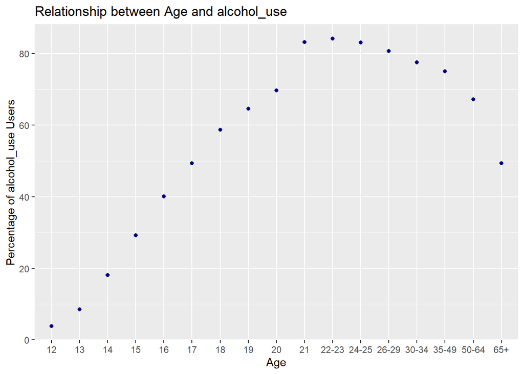

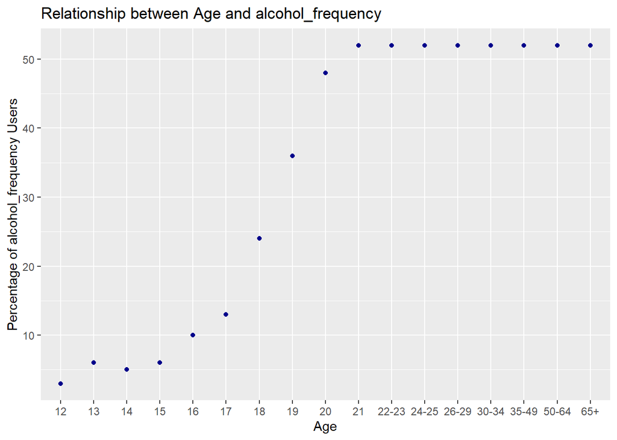

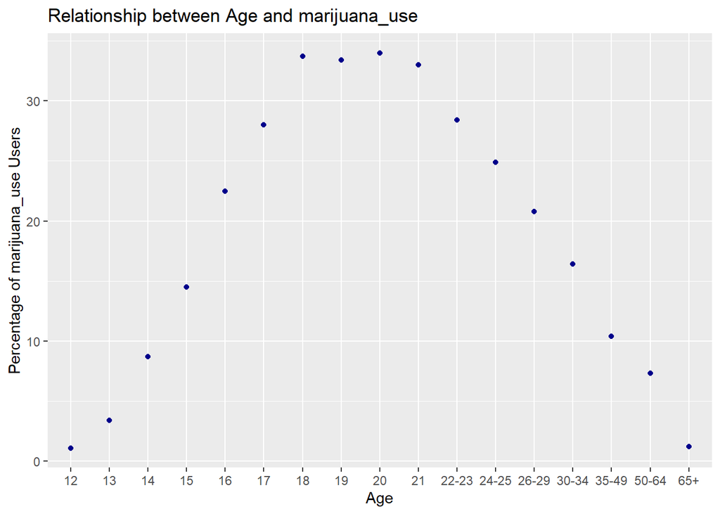

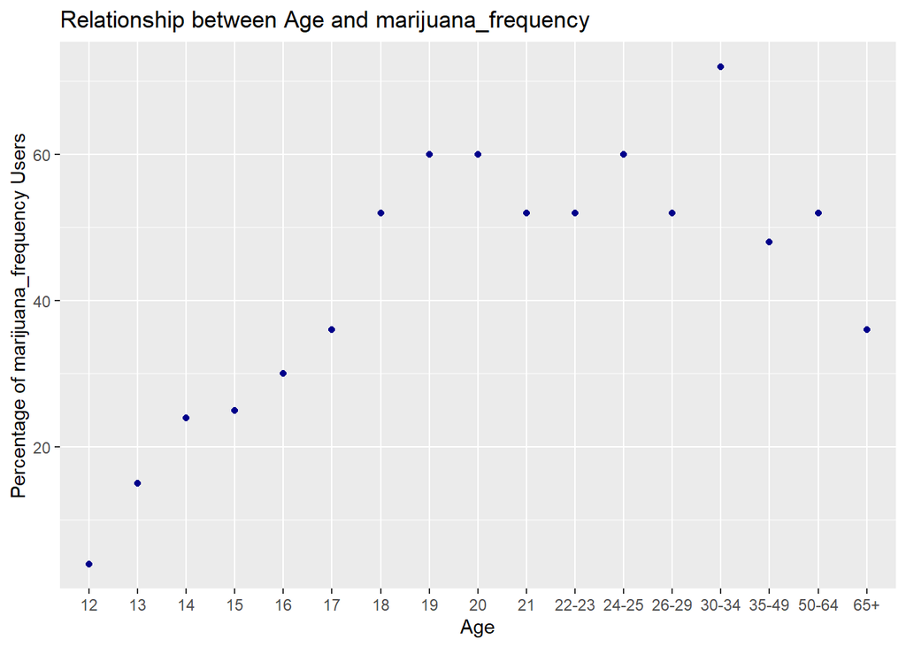

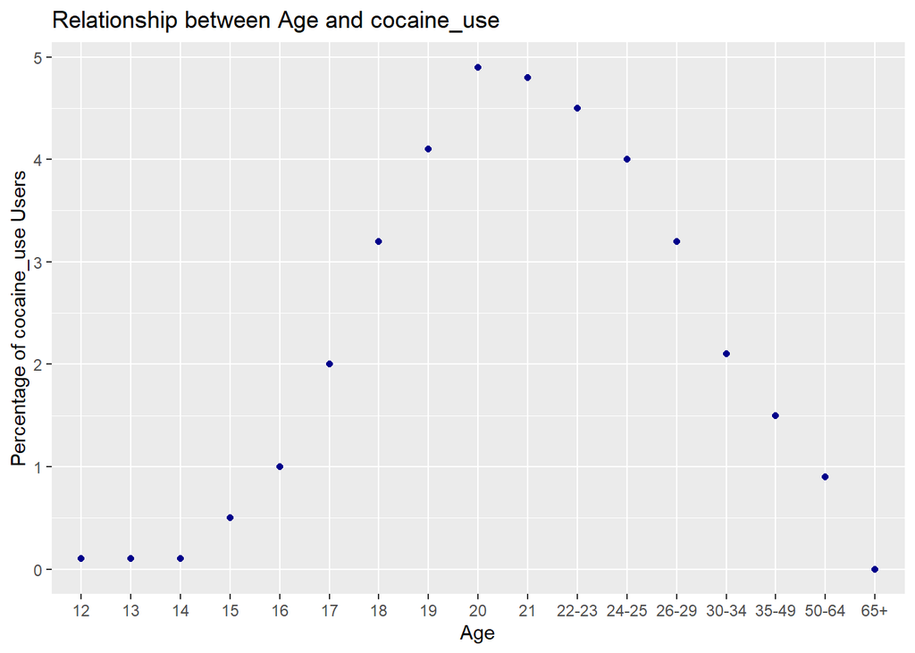

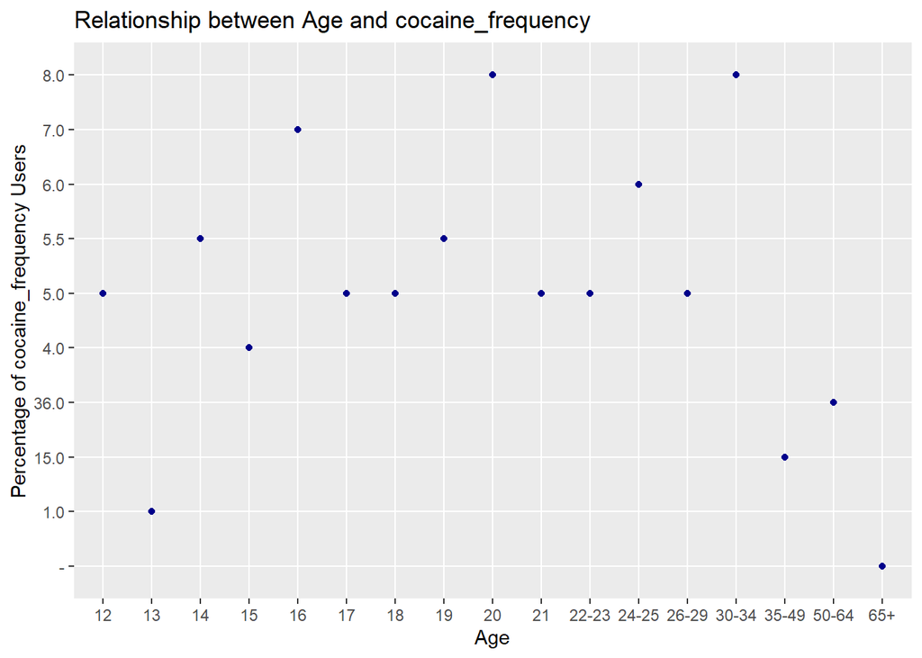

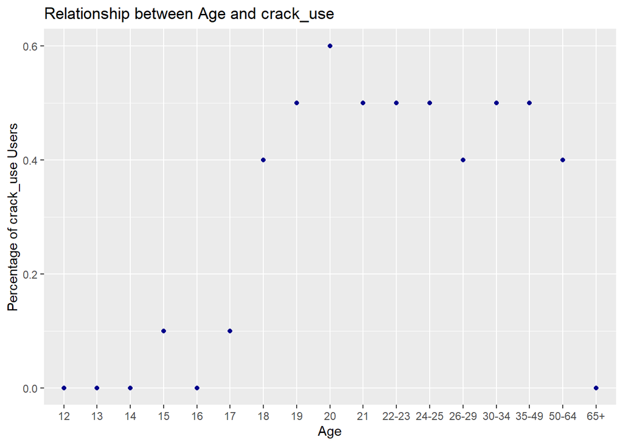

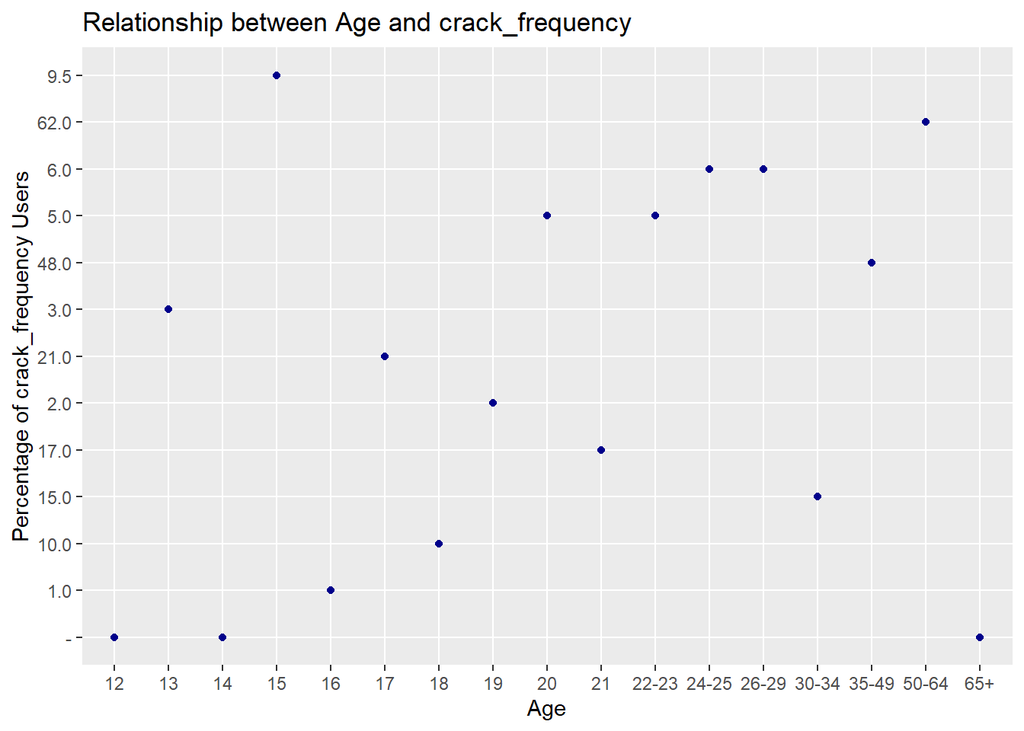

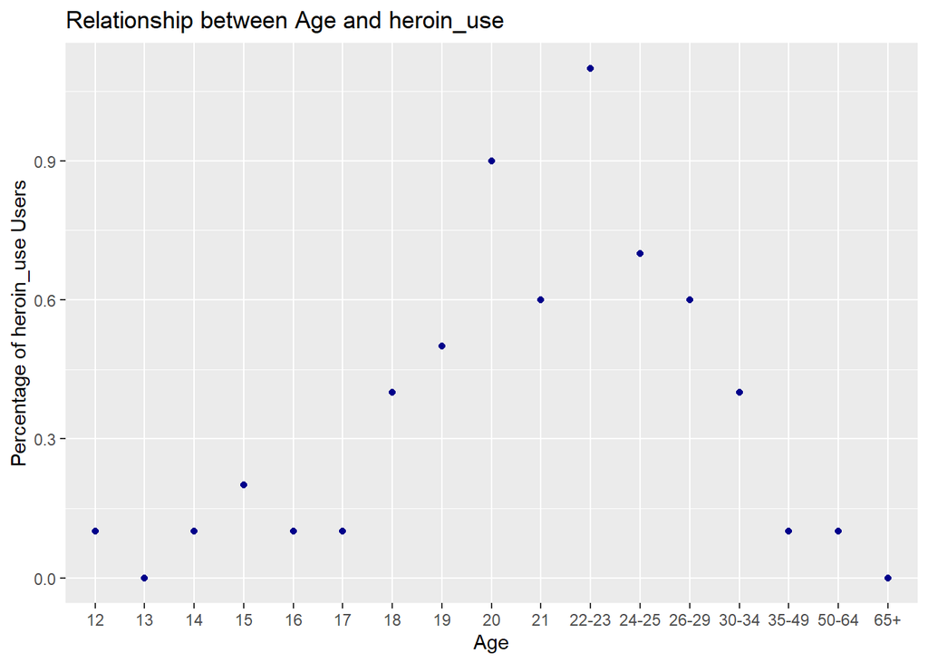

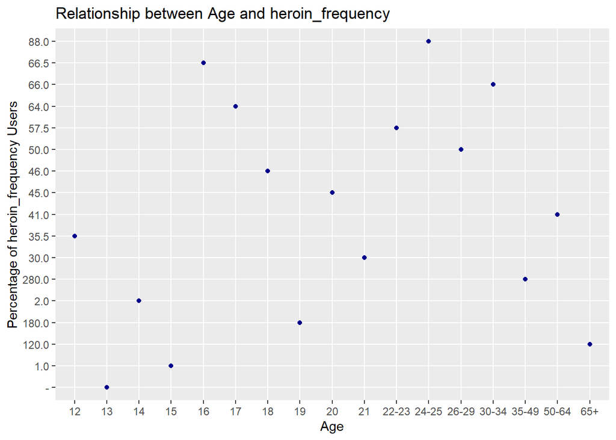

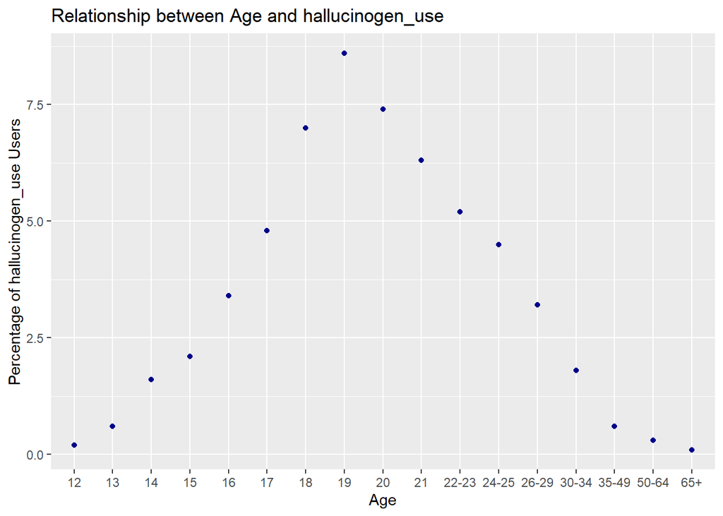

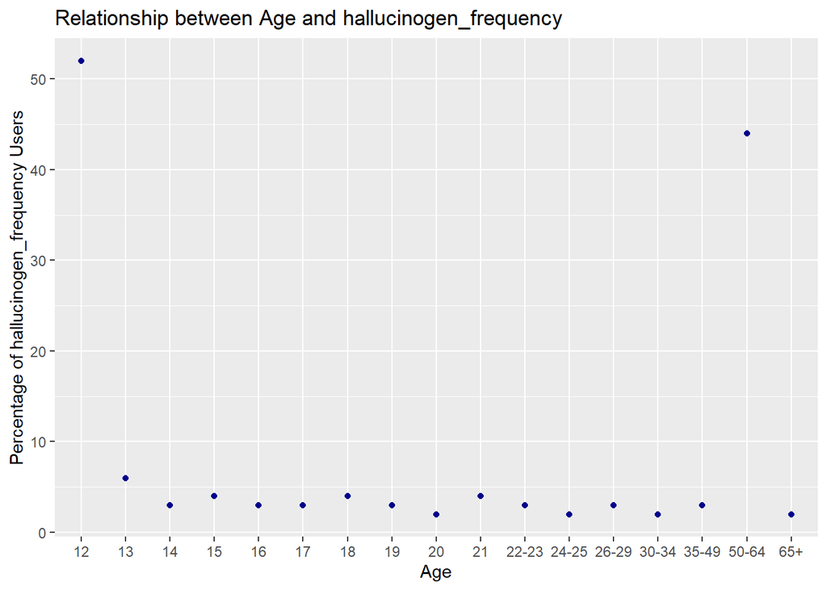

[14 more figures not shown]

```r
# Define a function to create scatterplots with linear regression lines
create_scatterplot <- function(data, drug_name) {
  ggplot(data, aes(x = age, y = !!sym(drug_name))) +
    geom_point(color = "darkblue") +
    geom_smooth(method = "lm", se = FALSE, color = "red") +
    labs(title = paste("Relationship between Age and", drug_name),
         x = "Age",
         y = paste("Percentage of", drug_name, "Users"))
}

# Create scatterplots for each drug
scatterplots <- lapply(names(drug_data)[3:ncol(drug_data)], function(drug_name) {
  create_scatterplot(drug_data, drug_name)
})

# Output the scatterplots
scatterplots
```

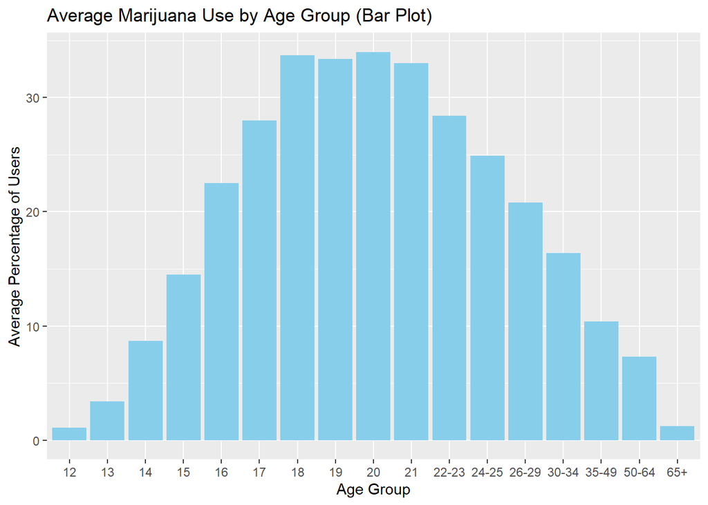

```r
# Bar plot of average marijuana use by age group
bar_plot <- ggplot(drug_data, aes(x = as.factor(age), y = marijuana_use)) +
  stat_summary(fun = mean, geom = "bar", fill = "skyblue") +
  labs(title = "Average Marijuana Use by Age Group (Bar Plot)",
       x = "Age Group",
       y = "Average Percentage of Users")

# Output the plots
list(bar_plot)
```

### Research question

**How does drug use vary by age, and are there any significant relationships, trends or patterns based on certain types of drugs?**

### Cases

**What are the cases, and how many are there?**

The cases are different age groups, ranging from 12 to 65+. There are 17 cases in total.

### Data collection

**Describe the method of data collection.**

The data was collected through surveys conducted by FiveThirtyEight. Source: National Survey on Drug Use and Health from the Substance Abuse and Mental Health Data Archive.

### Type of study

**What type of study is this (observational/experiment)?**

This study is observational.

### Data Source

**If you collected the data, state self-collected. If not, provide a citation/link.**

The data was collected by FiveThirtyEight and is publicly available on their GitHub repository. Source: National Survey on Drug Use and Health from the Substance Abuse and Mental Health Data Archive.

### Dependent Variable

**What is the response variable? Is it quantitative or qualitative?**

The response variable is the percentage of people who use each drug within different age groups. It is quantitative.

### Independent Variable(s)

Age is the independent variable in this study.

### Relevant summary statistics

**Provide summary statistics for each the variables. Also include appropriate visualizations related to your research question (e.g. scatter plot, boxplots, etc). This step requires the use of R, hence a code chunk is provided below. Insert more code chunks as needed.**

```r
# Summary statistics
summary(drug_data)
```

```
##      age                  n         alcohol_use    alcohol_frequency
##  Length:17          Min.   :2223   Min.   : 3.90   Min.   : 3.00
##  Class :character   1st Qu.:2469   1st Qu.:40.10   1st Qu.:10.00
##  Mode  :character   Median :2798   Median :64.60   Median :48.00
##                     Mean   :3251   Mean   :55.43   Mean   :33.35
##                     3rd Qu.:3058   3rd Qu.:77.50   3rd Qu.:52.00
##                     Max.   :7391   Max.   :84.20   Max.   :52.00
##  marijuana_use   marijuana_frequency  cocaine_use    cocaine_frequency
##  Min.   : 1.10   Min.   : 4.00       Min.   :0.000   Length:17
##  1st Qu.: 8.70   1st Qu.:30.00       1st Qu.:0.500   Class :character
##  Median :20.80   Median :52.00       Median :2.000   Mode  :character
##  Mean   :18.92   Mean   :42.94       Mean   :2.176
##  3rd Qu.:28.40   3rd Qu.:52.00       3rd Qu.:4.000
##  Max.   :34.00   Max.   :72.00       Max.   :4.900
##    crack_use      crack_frequency      heroin_use     heroin_frequency
##  Min.   :0.0000   Length:17          Min.   :0.0000   Length:17
##  1st Qu.:0.0000   Class :character   1st Qu.:0.1000   Class :character
##  Median :0.4000   Mode  :character   Median :0.2000   Mode  :character
##  Mean   :0.2941                      Mean   :0.3529
##  3rd Qu.:0.5000                      3rd Qu.:0.6000
##  Max.   :0.6000                      Max.   :1.1000
##  hallucinogen_use hallucinogen_frequency  inhalant_use   inhalant_frequency
##  Min.   :0.100    Min.   : 2.000         Min.   :0.000   Length:17
##  1st Qu.:0.600    1st Qu.: 3.000         1st Qu.:0.600   Class :character
##  Median :3.200    Median : 3.000         Median :1.400   Mode  :character
##  Mean   :3.394    Mean   : 8.412         Mean   :1.388
##  3rd Qu.:5.200    3rd Qu.: 4.000         3rd Qu.:2.000
##  Max.   :8.600    Max.   :52.000         Max.   :3.000
##  pain_releiver_use pain_releiver_frequency oxycontin_use    oxycontin_frequency
##  Min.   : 0.600    Min.   : 7.00           Min.   :0.0000   Length:17
##  1st Qu.: 3.900    1st Qu.:12.00           1st Qu.:0.4000   Class :character
##  Median : 6.200    Median :12.00           Median :1.1000   Mode  :character
##  Mean   : 6.271    Mean   :14.71           Mean   :0.9353
##  3rd Qu.: 9.000    3rd Qu.:15.00           3rd Qu.:1.4000
##  Max.   :10.000    Max.   :36.00           Max.   :1.7000
##  tranquilizer_use tranquilizer_frequency stimulant_use   stimulant_frequency
##  Min.   :0.200    Min.   : 4.50          Min.   :0.000   Min.   :  2.00
##  1st Qu.:1.400    1st Qu.: 6.00          1st Qu.:0.600   1st Qu.:  7.00
##  Median :3.500    Median :10.00          Median :1.800   Median : 10.00
##  Mean   :2.806    Mean   :11.74          Mean   :1.918   Mean   : 31.15
##  3rd Qu.:4.200    3rd Qu.:11.00          3rd Qu.:3.000   3rd Qu.: 12.00
##  Max.   :5.400    Max.   :52.00          Max.   :4.100   Max.   :364.00
##     meth_use      meth_frequency      sedative_use    sedative_frequency
##  Min.   :0.0000   Length:17          Min.   :0.0000   Min.   :  3.00
##  1st Qu.:0.2000   Class :character   1st Qu.:0.2000   1st Qu.:  6.50
##  Median :0.4000   Mode  :character   Median :0.3000   Median : 10.00
##  Mean   :0.3824                      Mean   :0.2824   Mean   : 19.38
##  3rd Qu.:0.6000                      3rd Qu.:0.4000   3rd Qu.: 17.50
##  Max.   :0.9000                      Max.   :0.5000   Max.   :104.00
```

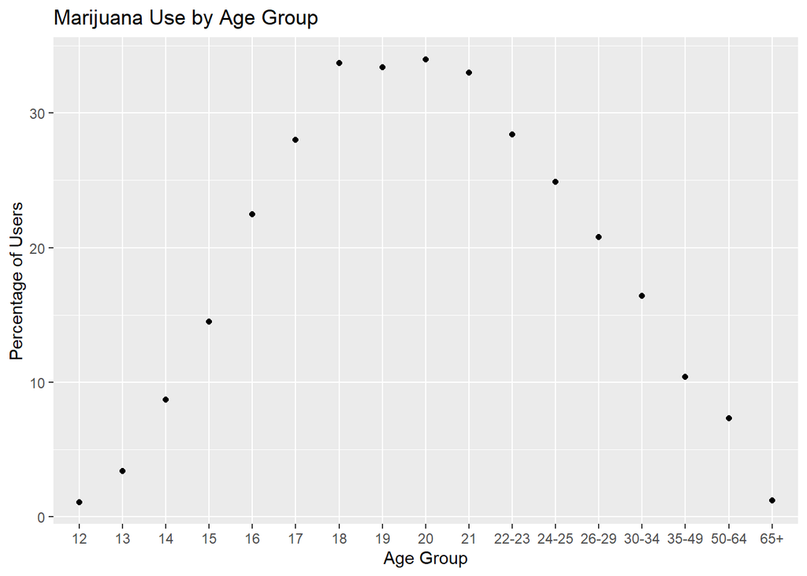

```r
# Visualizations
# Boxplot of marijuana use by age
ggplot(drug_data, aes(x = as.factor(age), y = marijuana_use)) +
  geom_point() +
  labs(title = "Marijuana Use by Age Group",
       x = "Age Group",
       y = "Percentage of Users")
```

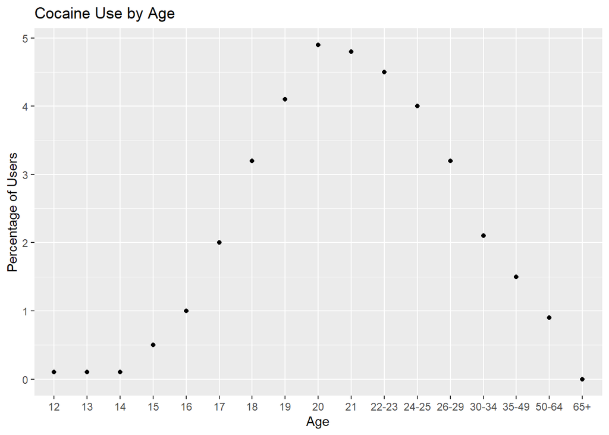

```r
# Scatterplot of cocaine use by age
ggplot(drug_data, aes(x = age, y = cocaine_use)) +
  geom_point() +
  labs(title = "Cocaine Use by Age",
       x = "Age",
       y = "Percentage of Users")
```